# Week 8: Tidy Data

Author

Affiliation

Joe Nese

University of Oregon  
Fall 2025

# Homework Review

Homework 8

# Tidy Data

Week 8

## Share

[`{tidylog}`](https://github.com/elbersb/tidylog)

- Provides feedback about `{dplyr}` and `{tidyr}` operations

view link

## How I feel about my `R` code sometimes

[figure not shown]

## Agenda

- Introduce the concept of tidy data
- Tidy a simple dataset together with `{tidyr}`
- Summarize and transform tidy data with `{dplyr}`

**Learning Objectives**

- Understand that the concept of tidy data is useful
- Understand and be able to apply the `pivot_longer()` and `pivot_wider()` functions

[figure not shown]

Credit [Allison Horst](https://allisonhorst.com/data-science-art)

## Providing grammar for:

- Graphics
  - `{ggplot2}`
- Data manipulations
  - `{dplyr}`
  - `{tidyr}`
- Expanding area of specialized topics
  - `{lubridate}`
  - `{glue}`
  - `{tidymodels}`
- Many more…

## Providing grammar for:

- Graphics
  - `{ggplot2}`
- Data manipulations
  - `{dplyr}`
  - `{tidyr}`
- Expanding area of specialized topics
  - `{lubridate}`
  - `{glue}`
  - `{tidymodels}`
- Many more…

# `{tidyr}`

## `{dplyr}` vs `{tidyr}`

`{dplyr}`

Helps you manipulate your data

- `select()`
- `filter()`
- `mutate()`
- `summarize()`
- more…

`{tidyr}`

Helps you get your data into a tidy format

- `pivot_longer()`
- `pivot_wider()`
- `separate_wider_position()` and `separate_wider_delim()`
- `separate_wider_regex()`
- `unite()`
- `nest()`

## Data cleaning

> “It is often said that 80% of data analysis is spent on the process of cleaning and preparing the data (Dasu & Johnson, 2003).” - Hadley Wickham (Tidy Data)

. . .

- Persistent and varied challenge
- Little research on how to do it well

## Activity

Run this code

```r
library(rio)
library(here)
library(tidyverse)

star <- import(here("data", "star.csv")) %>%
  as_tibble()
```

. . .

```
# A tibble: 5,748 × 12
   schidkn sex   frl   reg_size reg_size_aid small_size white black other totexp
     <int> <chr> <chr>    <int>        <int>      <int> <int> <int> <int>  <int>
 1      63 girl  no           0            0          1     1     0     0      7
 2      20 girl  no           0            0          1     0     1     0     21
 3      19 boy   yes          0            1          0     0     1     0      0
 4      69 boy   no           1            0          0     1     0     0     16
 5      79 boy   yes          0            0          1     1     0     0      5
 6       5 boy   yes          1            0          0     1     0     0      8
 7      16 girl  yes          0            1          0     0     1     0     17
 8      56 girl  no           1            0          0     1     0     0      3
 9      11 girl  no           0            0          1     0     1     0     11
10      66 girl  no           0            0          1     1     0     0     10
# ℹ 5,738 more rows
# ℹ 2 more variables: tmathss <int>, treadss <int>
```

## Produce this plot

What do we need here?

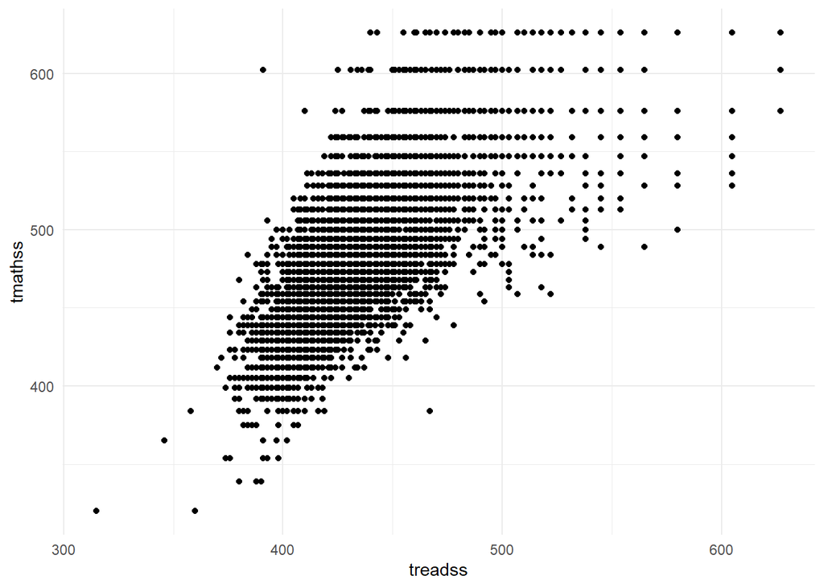

## Great! Now produce this plot

What’s different?

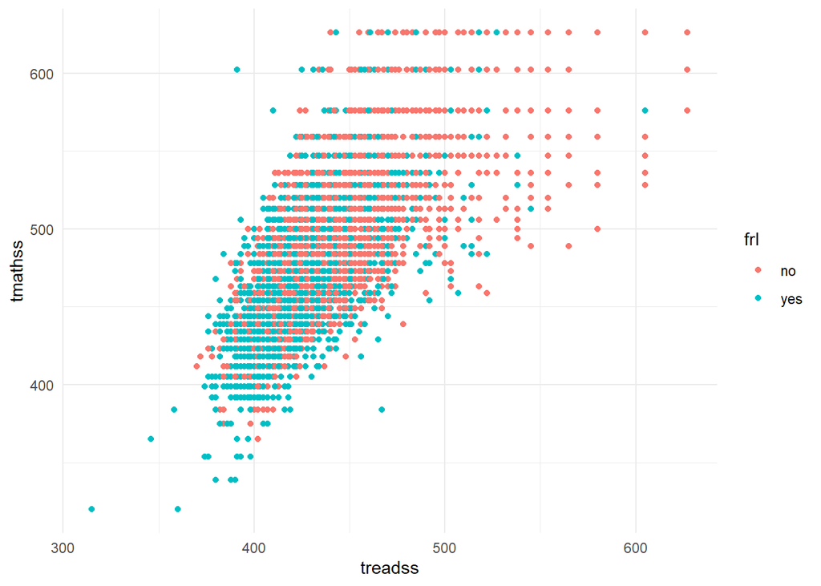

## Awesome! Now this one

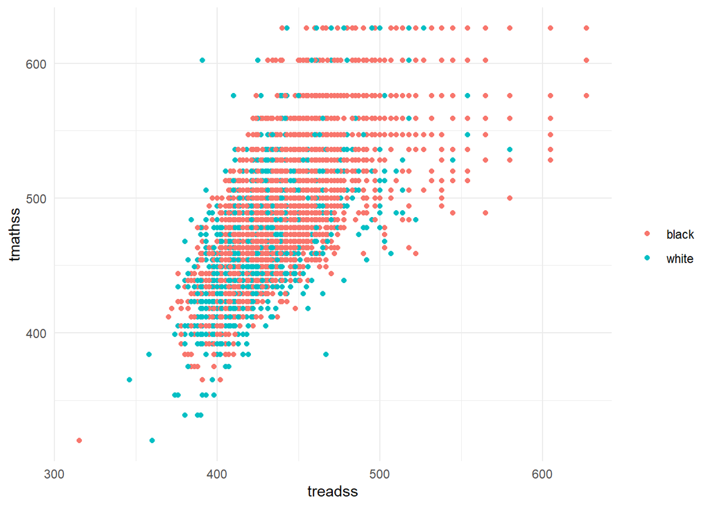

[figure not shown]

# Tidy Data

## Tidy Data

1. Each variable must have its own column
2. Each observation must have its own row
3. Each value must have its own cell

. . .

These three rules are interrelated because it’s impossible to only satisfy two of the three

[R4DS](https://r4ds.had.co.nz/tidy-data.html)

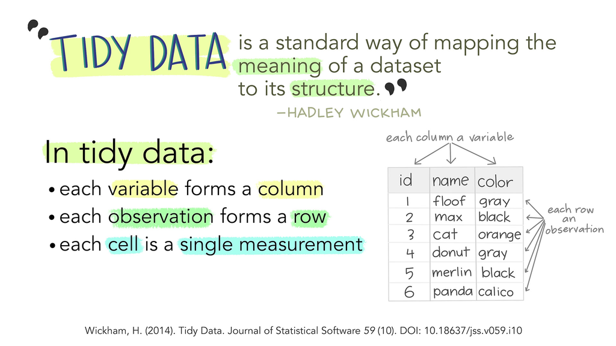

[Allison Horst](https://allisonhorst.com/other-r-fun)

## Tidy Data Made Simple

1. Put each dataset in a tibble
2. Put each variable in a column

## Why tidy?

A biased principled approach

- There are many reasons why you might want to have “messy” data
- **But**…
- If you have a consistent data structure, it’s easier to learn tools that work with it because the data has an underlying uniformity
- There’s a specific advantage to placing variables in columns because it allows R’s vectorised nature to be optimized
- Tidy data is an **extremely** useful format generally, and particularly useful when applying tools within the `{tidyverse}`
- All packages within the `{tidyverse}` are designed to either help you get your data in a tidy format, or assume your data are already in a tidy format
- Assuming a common data format leads to **huge** jumps in efficiency, as the output from certain functions can be directly input into others

## Common ways data are “messy”

- Column headers are values, not variable names
- Multiple variables stored in one column
- Variables are stored in both rows and columns
- See the pivoting [vignette](https://tidyr.tidyverse.org/articles/pivot.html) for examples and solutions

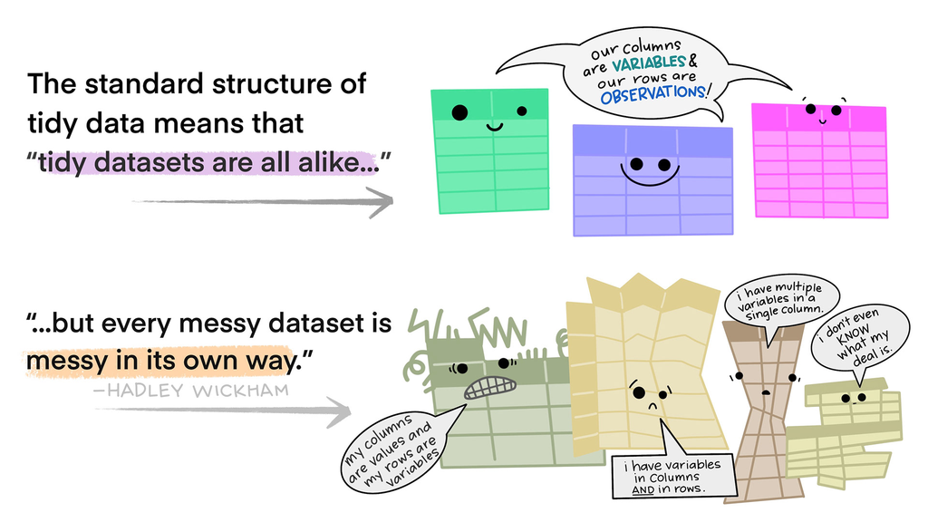

[Allison Horst](https://allisonhorst.com/other-r-fun)

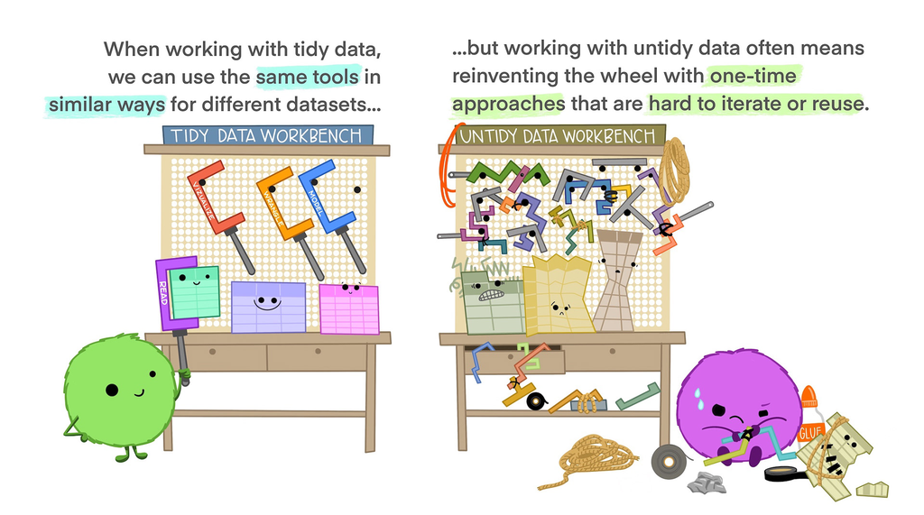

[Allison Horst](https://allisonhorst.com/other-r-fun)

[R4DS](https://r4ds.had.co.nz/tidy-data.html)

[figure not shown]

## `pivot_*()`

Talk with a neighbor about what you think `pivot_longer()` and `pivot_wider()` do

`01:30`

## `{tidyr}` verbs

**`pivot_longer()`**

“lengthens” data, increasing the number of rows and decreasing the number of columns

. . .

**`pivot_wider()`**

“widens” data, increasing the number of columns and decreasing the number of rows

. . .

**`separate_wider_position()` and `separate_wider_delim()`**

turns a single character column into multiple columns

. . .

**`separate_wider_regex()`**

given a [regular expression](https://r4ds.had.co.nz/strings.html#matching-patterns-with-regular-expressions) for capturing groups, turns each group into a new column

. . .

**`unite()`**

paste together multiple columns into one

. . .

**`nest()`**

creates a list-column of data frames; you get one row for each group defined by the non-nested columns. This is useful in conjunction with other summaries that work with whole datasets, like models

- **so** powerful